# Examen de Programación en R

Marcelo Andrés Yáñez Barrientos

08 de julio de 2025

```r
# Configuración inicial de knitr
knitr::opts_chunk$set(echo = TRUE, warning = FALSE, message = FALSE)
```

# Parte I: documentación de objetos en el proyecto

Librerias necesarias

```r
rm(list = ls())  # Limpiar entorno de trabajo para evitar conflictos
gc()             # Liberar memoria no utilizada
```

```
##           used (Mb) gc trigger (Mb) max used (Mb)
## Ncells  615409 32.9    1407287 75.2   702048 37.5
## Vcells 1152783  8.8    8388608 64.0  1928266 14.8
```

```r
# Lista de librerías requeridas
required_packages <- c("tidyverse", "knitr", "roxygen2", "devtools", "lubridate",
                       "plotly", "shiny", "readxl", "here", "testthat", "DT", "writexl")

# Función para instalar paquetes si no están instalados
install_if_missing <- function(pkg) {
  if (!require(pkg, character.only = TRUE)) {
    install.packages(pkg, dependencies = TRUE)
    library(pkg, character.only = TRUE)
  }
}

# Instalar y cargar librerías
lapply(required_packages, install_if_missing)
```

## Documentación del dataset

### Introducción

El Servicio de Impuestos Internos (SII) proporciona datos sobre personas jurídicas, incluyendo sus actividades económicas y direcciones, permitiendo analizar la concentración de industrias por sector según la Clasificación Industrial Internacional Uniforme (CIIU).

**Clasificación CIIU**

El código de actividad económica del SII tiene seis dígitos y su estructura es la siguiente:

- **Sección**: Letra (e.g., A, B).
- **División**: 2 dígitos
- **Clase**: 4 dígitos
- Nómina de actividades económicas  
  **Archivo PUB_NOM_ACTECOS.txt**  
  Listado de contribuyentes personas jurídicas con actividades económicas vigentes  
  (Actualización: mayo 2025, 3.574.193 registros)

  [Nómina de actividades económicas de contribuyentes personas jurídicas](https://www.sii.cl/estadisticas/nominas/PUB_NOM_ACTECOS.zip)
- Nómina de direcciones  
  **PUB_NOM_DOMICILIO.txt**  
  Listado de direcciones (Casa Matriz) vigentes y no vigentes  
  (Actualización: mayo 2025, 4.682.116 registros)

  [Nómina de direcciones personas jurídicas](https://www.sii.cl/estadisticas/nominas/PUB_NOM_DIRECCIONES.zip)]

### Bases y estructuras

- Estructura **PUB_NOM_ACTECOS.txt**

–RUT (chr): Identificador único del contribuyente (cualitativa, nominal)  
–DV (chr): Dígito verificador del RUT (cualitativa, nominal)  
–CODIGO ACTIVIDAD (chr): Código de actividad económica (cualitativa, nominal)  
–DESC. ACTIVIDAD ECONOMICA (chr): Descripción de la actividad (cualitativa, nominal)  
–FECHA (chr): Fecha de registro (cuantitativa, continua)  
–AFECTA A IVA (chr): Indica si afecta al IVA (“S” o “N”) (cualitativa, nominal)  
–CATEGORIA TRIBUTARIA (chr): Categoría tributaria (cualitativa, ordinal)

- Estructura **PUB_NOM_DOMICILIO.txt**

–RUT (chr): Identificador único (cualitativa, nominal)  
–DV (chr): Dígito verificador (cualitativa, nominal)  
–VIGENCIA (chr): Estado del domicilio (“S” o “N”) (cualitativa, nominal)  
–FECHA (chr): Fecha de registro de la empresa (cuantitativa, continua)  
–TIPO_DIRECCION (chr): Tipo de dirección de la empresa (e.g., “MATRIZ”) (cualitativa, nominal)  
–CALLE (chr): Nombre de la calle de la empresa (cualitativa, nominal)  
–NUMERO (chr): Número de la dirección de la empresa (cualitativa, nominal)  
–BLOQUE (chr): Bloque del domicilio (cualitativa, nominal)  
–DEPARTAMENTO (chr): Número de departamento de la empresa (cualitativa, nominal)  
–VILLA_POBLACION (chr): Villa o población (cualitativa, nominal)  
–CIUDAD (chr): Ciudad de la empresa (cualitativa, nominal)  
–COMUNA (chr): Comuna de la empresa (cualitativa, nominal)  
–REGION (chr): Región de la empresa (cualitativa, nominal)

Después del análisis de la cátedra se unen las bases y se transforman en una nueva base llamada Data_SII, la cual se integrará con Nvl_Act_eco, para el desarrollo del Dashboard en Shiny. Por ejemplo, mostrará gráficos interactivos de actividades económicas por región según su sección, división o clase.

### Archivos:

– Data_SII.txt: Base integrada para el dashboard Shiny  
– Nvl_Act_eco.txt: Niveles de actividad económica

- Estructura **Data_SII.txt**

  – actividad (chr): Código de actividad económica (cualitativa, nominal)  
  – seccion(chr): Código de actividad económica (cualitativa, nominal)  
  – division (chr): División CIIU (cualitativa, nominal)  
  – fec_actividad (chr): Fecha de registro actividad (cuantitativa, continua)  
  – region (chr): Región de la empresa (cualitativa, nominal)  
  – fec_region (chr): Fecha de registro del domicilio de la empresa (cuantitativa, continua)
- Estructura **Nvl_Act_eco.txt** “Niveles actividad económica”

  –seccion (chr): Sección CIIU (cualitativa, nominal)  
  –gls_seccion (chr): Descripción de la sección (cualitativa, nominal)  
  –division (chr): División CIIU (cualitativa, nominal)  
  –gls_division (chr): Descripción de la división (cualitativa, nominal)  
  –grupo (chr): Grupo CIIU (cualitativa, nominal)  
  –gls_grupo (chr): Descripción del grupo (cualitativa, nominal)  
  –clase (chr): Clase CIIU (cualitativa, nominal)  
  –gls_clase (chr): Descripción de la clase (cualitativa, nominal)  
  (3.574. 173 registros)

## Documentación de funciones

La siguiente sección presenta las funciones desarrolladas para el proyecto, cada una documentada con el estándar Roxygen2 para facilitar su comprensión y uso.

Función cargar_archivo

La función cargar_archivo está diseñada para cargar archivos de texto (.txt, .csv) o Excel (.xlsx, .xls) en un tibble de R, con una útil detección automática de delimitadores para los archivos de texto. Además, ofrece la opción de asignar el tibble resultante directamente al entorno global para un acceso más fácil.

```r
#' @title Cargar archivo en la raíz del proyecto con delimitador automático
#'
#' @description
#' Esta función carga archivos de texto (.txt, .csv) o Excel (.xlsx, .xls) en un tibble de R, con detección automática de delimitadores para archivos de texto. Ofrece la opción de asignar el tibble al entorno global.
#'
#' @param nombre_archivo Nombre del archivo (relativo a la raíz del proyecto).
#' @param asignar_globalmente Logical: Si TRUE, asigna el tibble al entorno global (default: TRUE).
#' @param ... Argumentos adicionales para read_delim o read_excel.
#'
#' @return Tibble con los datos cargados o NULL en caso de error.
#' @export
cargar_archivo <- function(nombre_archivo, asignar_globalmente = TRUE, ...) {

  # Construir ruta completa usando here::here
  ruta_archivo <- here::here(nombre_archivo)

  # Validar existencia del archivo
  if (!file.exists(ruta_archivo)) {
    message(paste0("ERROR: El archivo '", ruta_archivo, "' no existe en el proyecto."))
    return(NULL)
  }

  # Generar nombre limpio para el objeto
  nombre_base <- basename(ruta_archivo)
  nombre_objeto <- tools::file_path_sans_ext(nombre_base) %>%
    str_replace_all("[^a-zA-Z0-9_]", "") %>%
    { if (str_detect(., "^[0-9]")) paste0("datos_", .) else . }
  if (nchar(nombre_objeto) == 0) {
    nombre_objeto <- "datos_genericos"
    warning("Nombre de objeto inválido. Usando 'datos_genericos'.")
  }

  # Detectar si es Excel
  extension <- tolower(tools::file_ext(ruta_archivo))
  is_excel <- extension %in% c("xls", "xlsx")

  # Detección automática de delimitador para archivos de texto
  detectar_delimitador <- function(ruta, posibles = c(",", "\t", ";", "|")) {
    linea <- readLines(ruta, n = 1)
    conteos <- sapply(posibles, function(d) str_count(linea, fixed(d)))
    if (all(conteos == 0)) return(",")
    posibles[which.max(conteos)]
  }

  # Cargar el archivo
  datos_cargados <- tryCatch({
    if (is_excel) {
      readxl::read_excel(ruta_archivo, ...)
    } else {
      delim <- detectar_delimitador(ruta_archivo)
      readr::read_delim(ruta_archivo, delim = delim, escape_double = FALSE, trim_ws = TRUE, show_col_types = FALSE, ...)
    }
  }, error = function(e) {
    message(paste0("ERROR al cargar '", nombre_base, "': ", e$message))
    return(NULL)
  })

  if (is.null(datos_cargados)) return(NULL)

  # Convertir a tibble
  datos_tibble <- as_tibble(datos_cargados)

  # Asignar al entorno global si se indica
  if (asignar_globalmente) {
    assign(nombre_objeto, datos_tibble, envir = .GlobalEnv)
    message(paste0("Archivo '", nombre_base, "' cargado como '", nombre_objeto, "' en el entorno global."))
  }

  return(datos_tibble)
}
```

La función analizar_distribuciones es una herramienta para comprender la composición de tus datos, actividades económicas (CIIU) y ubicación geográfica por región.

Genera tablas de conteo como gráficos de barras.

```r
#' @title Analizar y visualizar distribuciones de datos
#'
#' @description
#' Esta función calcula y opcionalmente visualiza las distribuciones de frecuencia de las actividades económicas (CIIU, por sección o división) y por región en un conjunto de datos. Permite personalización de colores y temas de ggplot2.
#'
#' @param datos Data.frame o tibble con los datos.
#' @param agrupar_ciiu Character: "seccion" (default) o "division".
#' @param color_ciiu Character: Color para gráfico CIIU (default: "steelblue").
#' @param color_region Character: Color para gráfico región (default: "darkgreen").
#' @param tema_ggplot Character: Tema de ggplot2 (default: "theme_minimal").
#' @param retorno Character: "tablas", "graficos" o "ambos" (default).
#'
#' @return Lista con tablas y/o gráficos según `retorno`.
#' @export
analizar_distribuciones <- function(datos, agrupar_ciiu = "seccion", color_ciiu = "steelblue",
                                    color_region = "darkgreen", tema_ggplot = "theme_minimal", retorno = "ambos") {

  # Validaciones
  if (!is.data.frame(datos)) stop("datos debe ser un data.frame o tibble.")
  if (!agrupar_ciiu %in% c("seccion", "division")) stop("agrupar_ciiu debe ser 'seccion' o 'division'.")
  if (!retorno %in% c("tablas", "graficos", "ambos")) stop("retorno debe ser 'tablas', 'graficos' o 'ambos'.")

  cols_req <- c(agrupar_ciiu, "region")
  missing_cols <- setdiff(cols_req, names(datos))
  if (length(missing_cols) > 0) stop(paste("Faltan columnas:", paste(missing_cols, collapse = ", ")))

  tema_func <- match.fun(tema_ggplot)

  # Tablas de frecuencia
  tabla_ciiu <- datos %>%
    count(!!sym(agrupar_ciiu)) %>%
    arrange(desc(n)) %>%
    rename_with(~ agrupar_ciiu, 1)

  tabla_region <- datos %>%
    count(region) %>%
    arrange(desc(n))

  tablas <- list(ciiu = tabla_ciiu, region = tabla_region)

  # Gráficos si se solicitan
  if (retorno %in% c("graficos", "ambos")) {
    graf_ciiu <- ggplot(tabla_ciiu, aes(x = reorder(!!sym(agrupar_ciiu), -n), y = n, fill = color_ciiu)) +
      geom_bar(stat = "identity") +
      labs(title = paste("Distribución por", toupper(agrupar_ciiu)), x = agrupar_ciiu, y = "Frecuencia") +
      theme(axis.text.x = element_text(angle = 45, hjust = 1, vjust = 1)) +
      scale_fill_manual(values = color_ciiu) +
      tema_func() +
      theme(legend.position = "none")

    graf_region <- ggplot(tabla_region, aes(x = reorder(region, -n), y = n, fill = color_region)) +
      geom_bar(stat = "identity") +
      labs(title = "Distribución por Región", x = "Región", y = "Frecuencia") +
      theme(axis.text.x = element_text(angle = 45, hjust = 1, vjust = 1)) +
      scale_fill_manual(values = color_region) +
      tema_func() +
      theme(legend.position = "none")

    graficos <- list(ciiu = graf_ciiu, region = graf_region)
  }

  # Retorno
  if (retorno == "tablas") return(list(tablas = tablas))
  if (retorno == "graficos") return(list(graficos = graficos))
  return(list(tablas = tablas, graficos = graficos))
}
```

## Documentación de Clases S3

### S3 para cargar_archivo

```r
#' @title Cargar archivo en la raíz del proyecto con delimitador automático (Genérica S3)
#'
#' @description
#' Función genérica S3 para cargar archivos.
#'
#' @param x Objeto sobre el que se despacha el método (e.g., character para nombre del archivo).
#' @param ... Argumentos adicionales.
#'
#' @return Tibble con datos cargados.
#' @export
cargar_archivo <- function(x, ...) {
  UseMethod("cargar_archivo")
}

#' @method cargar_archivo character
#' @export
cargar_archivo.character <- function(nombre_archivo, asignar_globalmente = TRUE, ...) {
  # Código de la función original aquí (copiado y ajustado si es necesario)
  ruta_archivo <- here::here(nombre_archivo)
  if (!file.exists(ruta_archivo)) {
    message(paste0("ERROR: El archivo '", ruta_archivo, "' no existe."))
    return(NULL)
  }

  nombre_base <- basename(ruta_archivo)
  nombre_objeto <- tools::file_path_sans_ext(nombre_base) %>%
    str_replace_all("[^a-zA-Z0-9_]", "") %>%
    { if (str_detect(., "^[0-9]")) paste0("datos_", .) else . }
  if (nchar(nombre_objeto) == 0) {
    nombre_objeto <- "datos_genericos"
    warning("Nombre inválido. Usando 'datos_genericos'.")
  }

  extension <- tolower(tools::file_ext(ruta_archivo))
  is_excel <- extension %in% c("xls", "xlsx")

  detectar_delimitador <- function(ruta, posibles = c(",", "\t", ";", "|")) {
    linea <- readLines(ruta, n = 1)
    conteos <- sapply(posibles, function(d) str_count(linea, fixed(d)))
    if (all(conteos == 0)) return(",")
    posibles[which.max(conteos)]
  }

  datos_cargados <- tryCatch({
    if (is_excel) {
      readxl::read_excel(ruta_archivo, ...)
    } else {
      delim <- detectar_delimitador(ruta_archivo)
      readr::read_delim(ruta_archivo, delim = delim, escape_double = FALSE, trim_ws = TRUE, show_col_types = FALSE, ...)
    }
  }, error = function(e) {
    message(paste0("ERROR al cargar '", nombre_base, "': ", e$message))
    NULL
  })

  if (is.null(datos_cargados)) return(NULL)

  datos_tibble <- as_tibble(datos_cargados)

  if (asignar_globalmente) {
    assign(nombre_objeto, datos_tibble, envir = .GlobalEnv)
    message(paste0("Archivo '", nombre_base, "' cargado como '", nombre_objeto, "'."))
  }

  return(datos_tibble)
}
```

### S3 para analizar_distribuciones

Primero, creamos la función genérica analizar_distribuciones. Esta función será la “puerta de entrada” y, dependiendo de la clase del primer argumento (datos), llamará al método específico adecuado.

```r
#' @title Analizar y visualizar distribuciones de datos
#'
#' @description
#' `analizar_distribuciones` es una función genérica S3 para calcular y
#' opcionalmente visualizar las distribuciones de frecuencia de actividades
#' económicas (CIIU) y regiones en conjuntos de datos.
#'
#' @param datos Un objeto sobre el cual el método será despachado (ej. un `data.frame`).
#' @param ... Argumentos adicionales pasados a los métodos específicos.
#'
#' @return El resultado del método S3 despachado.
#' @export
analizar_distribuciones <- function(datos, ...) {
  UseMethod("analizar_distribuciones")
}
```

Segundo, definir el método específico para data.frame.

Ahora, creamos el método analizar_distribuciones

```r
#' @title Método S3 para analizar distribuciones en data.frames
#'
#' @description
#' Método específico para data.frames de la función genérica `analizar_distribuciones`.
#' Calcula y opcionalmente visualiza distribuciones de frecuencia por CIIU (sección o división)
#' y región.
#'
#' @param datos Un data.frame o tibble con columnas requeridas (al menos "seccion", "division" y "region").
#' @param agrupar_ciiu Character: "seccion" (default) o "division".
#' @param color_ciiu Character: Color para barras del gráfico CIIU (default: "steelblue").
#' @param color_region Character: Color para barras del gráfico región (default: "darkgreen").
#' @param tema_ggplot Character: Tema de ggplot2 (default: "theme_minimal").
#' @param retorno Character: "tablas", "graficos" o "ambos" (default).
#' @param ... Argumentos adicionales (no usados en este método).
#'
#' @return Lista con tablas y/o gráficos según `retorno`.
#' @export
analizar_distribuciones.data.frame <- function(datos,
                                               agrupar_ciiu = "seccion",
                                               color_ciiu = "steelblue",
                                               color_region = "darkgreen",
                                               tema_ggplot = "theme_minimal",
                                               retorno = "ambos",
                                               ...) {

  # Validación de entradas
  if (!is.data.frame(datos)) {
    stop("El argumento 'datos' debe ser un data.frame o tibble.")
  }
  if (!agrupar_ciiu %in% c("seccion", "division")) {
    stop("El argumento 'agrupar_ciiu' debe ser 'seccion' o 'division'.")
  }
  if (!retorno %in% c("tablas", "graficos", "ambos")) {
    stop("El argumento 'retorno' debe ser 'tablas', 'graficos' o 'ambos'.")
  }

  # Verificar columnas requeridas
  cols_req <- c(agrupar_ciiu, "region")
  missing_cols <- setdiff(cols_req, names(datos))
  if (length(missing_cols) > 0) {
    stop(paste("Faltan columnas requeridas:", paste(missing_cols, collapse = ", ")))
  }

  # Validar tema de ggplot
  tema_func <- tryCatch(get(tema_ggplot, envir = asNamespace("ggplot2")), error = function(e) NULL)
  if (!is.function(tema_func)) {
    stop(paste("El tema de ggplot '", tema_ggplot, "' no es una función válida."))
  }

  # Cálculo de tablas de frecuencia
  tabla_ciiu <- datos %>%
    dplyr::count(!!sym(agrupar_ciiu)) %>%
    dplyr::arrange(desc(n)) %>%
    dplyr::rename_with(~ agrupar_ciiu, 1)

  tabla_region <- datos %>%
    dplyr::count(region) %>%
    dplyr::arrange(desc(n))

  tablas <- list(ciiu = tabla_ciiu, region = tabla_region)

  # Generación de gráficos (si se solicita)
  if (retorno %in% c("graficos", "ambos")) {
    graf_ciiu <- ggplot(tabla_ciiu, aes(x = reorder(!!sym(agrupar_ciiu), -n), y = n)) +
      geom_bar(stat = "identity", fill = color_ciiu) +
      labs(title = paste("Distribución por", toupper(agrupar_ciiu)), x = agrupar_ciiu, y = "Frecuencia") +
      theme(axis.text.x = element_text(angle = 45, hjust = 1)) +
      tema_func()

    graf_region <- ggplot(tabla_region, aes(x = reorder(region, -n), y = n)) +
      geom_bar(stat = "identity", fill = color_region) +
      labs(title = "Distribución por Región", x = "Región", y = "Frecuencia") +
      theme(axis.text.x = element_text(angle = 45, hjust = 1)) +
      tema_func()

    graficos <- list(ciiu = graf_ciiu, region = graf_region)
  }

  # Retorno según lo solicitado
  if (retorno == "tablas") return(list(tablas = tablas))
  if (retorno == "graficos") return(list(graficos = graficos))
  return(list(tablas = tablas, graficos = graficos))
}
```

- probar funcion s3

```r
# Datos de ejemplo para probar la función S3 genérica y el método .data.frame
datos_ejemplo <- data.frame(
  seccion = sample(LETTERS[1:5], 100, replace = TRUE),
  division = sample(10:15, 100, replace = TRUE),
  region = sample(c("RM", "BioBio", "Valparaiso"), 100, replace = TRUE)
)

# Llamada a la genérica (despacha al método .data.frame)
resultados <- analizar_distribuciones(datos_ejemplo, agrupar_ciiu = "division", retorno = "ambos")

# Visualizar resultados
print(resultados$tablas$ciiu)
```

```
##   division  n
## 1       14 24
## 2       13 17
## 3       15 17
## 4       12 15
## 5       10 14
## 6       11 13
```

```r
print(resultados$tablas$region)
```

```
##       region  n
## 1         RM 37
## 2 Valparaiso 32
## 3     BioBio 31
```

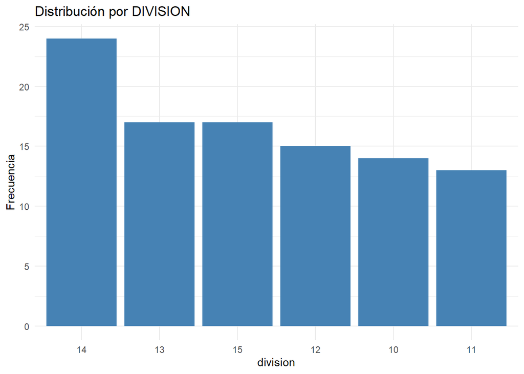

```r
print(resultados$graficos$ciiu)
```

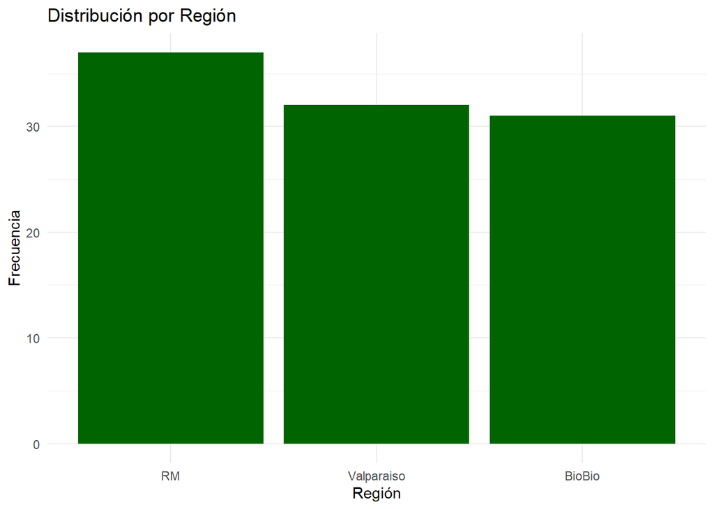

```r
print(resultados$graficos$region)
```

```r
# Probar con clase explícita (aunque tibble hereda de data.frame)
class(datos_ejemplo) <- c("tbl_df", "data.frame")
resultados_tbl <- analizar_distribuciones(datos_ejemplo)
print(resultados_tbl$tablas$ciiu)  # Debe funcionar igual
```

```
##   seccion  n
## 1       E 28
## 2       B 24
## 3       C 20
## 4       D 15
## 5       A 13
```

# Parte II: Testeo de funciones

## Flujo de trabajo de testeo

Se utiliza el paquete `testthat` para pruebas unitarias, siguiendo las mejores prácticas descritas en “R Packages” de Hadley Wickham. Las pruebas se almacenan en el directorio `tests/testthat/` y se ejecutan con `devtools::test()`.

## Estructura del test

Cada prueba verifica:

1. **Entradas válidas**: Comprobar que las funciones procesan correctamente datos correctos.
2. **Manejo de errores**: Validar que las funciones devuelven errores apropiados para entradas inválidas.
3. **Resultados esperados**: Confirmar que las salidas tienen el formato y valores esperados.

## Ejemplo de pruebas

### Pruebas para analizar_distribuciones

```r
test_that("analizar_distribuciones genera tablas y gráficos correctos", {
  # Datos de ejemplo (sin cambios)
  datos_ejemplo <- data.frame(
    seccion = sample(LETTERS[1:5], 100, replace = TRUE),
    division = sample(10:15, 100, replace = TRUE),
    region = sample(c("RM", "BioBio", "Valparaiso"), 100, replace = TRUE)
  )

  # Prueba por defecto (seccion, ambos) - sin cambios
  resultados <- analizar_distribuciones(datos_ejemplo)
  expect_type(resultados, "list")
  expect_length(resultados, 2)
  expect_named(resultados, c("tablas", "graficos"))

  # Comprobar tablas - sin cambios
  expect_type(resultados$tablas, "list")
  expect_length(resultados$tablas, 2)
  expect_s3_class(resultados$tablas$ciiu, "data.frame")
  expect_s3_class(resultados$tablas$region, "data.frame")
  expect_named(resultados$tablas$ciiu, c("seccion", "n"))
  expect_named(resultados$tablas$region, c("region", "n"))
  expect_true(all(resultados$tablas$ciiu$n > 0))
  expect_equal(sum(resultados$tablas$ciiu$n), 100)
  expect_equal(sum(resultados$tablas$region$n), 100)

  # Comprobar gráficos - sin cambios
  expect_type(resultados$graficos, "list")
  expect_length(resultados$graficos, 2)
  expect_s3_class(resultados$graficos$ciiu, "ggplot")
  expect_s3_class(resultados$graficos$region, "ggplot")

  # Prueba con agrupar_ciiu = "division", solo tablas - sin cambios
  resultados_tablas <- analizar_distribuciones(datos_ejemplo, agrupar_ciiu = "division", retorno = "tablas")
  expect_type(resultados_tablas, "list")
  expect_length(resultados_tablas, 1)
  expect_named(resultados_tablas$tablas$ciiu, c("division", "n"))

  # Prueba con retorno = "graficos" - sin cambios
  resultados_graficos <- analizar_distribuciones(datos_ejemplo, retorno = "graficos")
  expect_type(resultados_graficos, "list")
  expect_length(resultados_graficos, 1)
  expect_s3_class(resultados_graficos$graficos$ciiu, "ggplot")

  # Prueba con tema personalizado y colores - sin cambios
  resultados_custom <- analizar_distribuciones(
    datos_ejemplo,
    color_ciiu = "purple",
    color_region = "orange",
    tema_ggplot = "theme_bw"
  )
  expect_s3_class(resultados_custom$graficos$ciiu, "ggplot")
})
```

```
## Test passed 🎊
```

### **Referencias**

- RStudio Community. (2023). Guía de testthat.